# MarketMixModeling

Alan

2025-01-17

## Introduction

This project demonstrates the use of mixed marketing models to analyze the relationship between marketing channel spends and sales outcomes. We will also explore multi-touch attribution to understand the contribution of each channel.

## Data Collection

We will use the `marketing` dataset from the `datarium` package, which contains weekly sales data and advertising spends across different channels.

```r
library(datarium)
library(tidyr)

# Load marketing data
data(marketing)
sampledf <- marketing

# View the structure and content of the data
str(sampledf)
```

```
## 'data.frame':    200 obs. of  4 variables:
##  $ youtube  : num  276.1 53.4 20.6 181.8 217 ...
##  $ facebook : num  45.4 47.2 55.1 49.6 13 ...
##  $ newspaper: num  83 54.1 83.2 70.2 70.1 ...
##  $ sales    : num  26.5 12.5 11.2 22.2 15.5 ...
```

## Data Exploration

### Overview of the Data

We assume each observation describes weekly sales in chronological order.

```r
sampledf$week <- (-length(sampledf$sales)+1):0
```

### Exploratory Data Analysis (EDA)

Let’s explore the relationships between sales and advertising channels.

```r
library(PerformanceAnalytics)
```

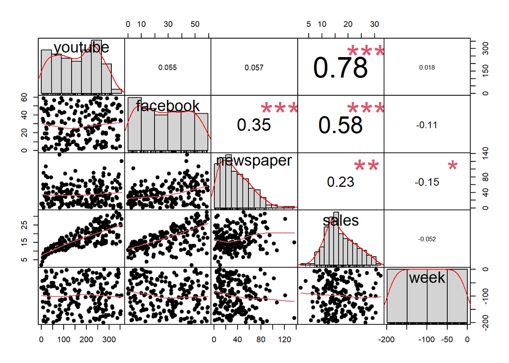

```r
# Plot correlation matrix with histograms
chart.Correlation(sampledf, histogram = TRUE, pch=19)
```

Sales seems to be correlated with advertising across channels, as expected. The correlation of facebook and newspaper is also not troublesome as it is probably explained by time (at certain episodes there was more advertising on this channels in general).

### Time Dimension Analysis

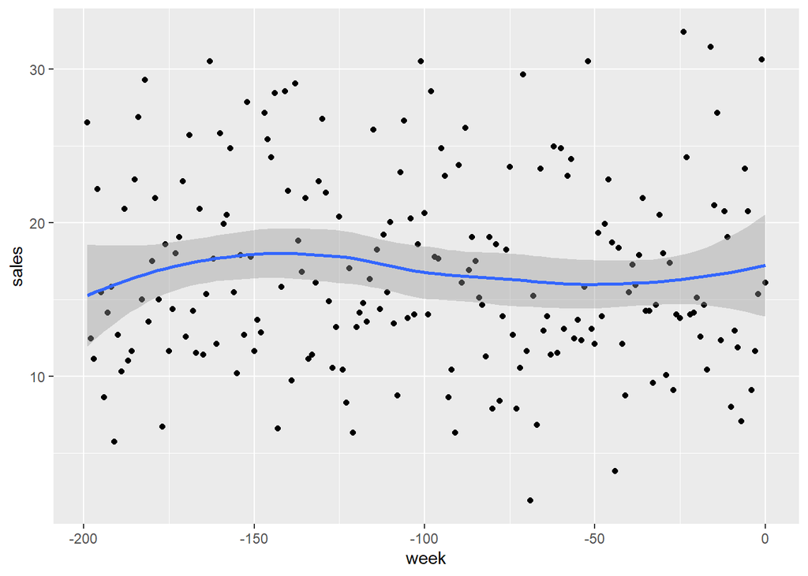

```r
library(ggplot2)

# Plot sales over time
sampledf %>% ggplot(aes(week, sales)) + geom_point() + geom_smooth()
```

### Investigating Seasonality with Bayesian Prophet Model

```r
library(prophet)
library(dplyr)
# Prepare data for Prophet model
sampledf_prophet <- sampledf %>% mutate(ds = as.Date(week*7, origin = "1970-01-01"), y = sales)

# Fit the model
m <- prophet(sampledf_prophet, mcmc.samples = 1000)
```

```
## Disabling weekly seasonality. Run prophet with weekly.seasonality=TRUE to override this.
```

```
## Disabling daily seasonality. Run prophet with daily.seasonality=TRUE to override this.
```

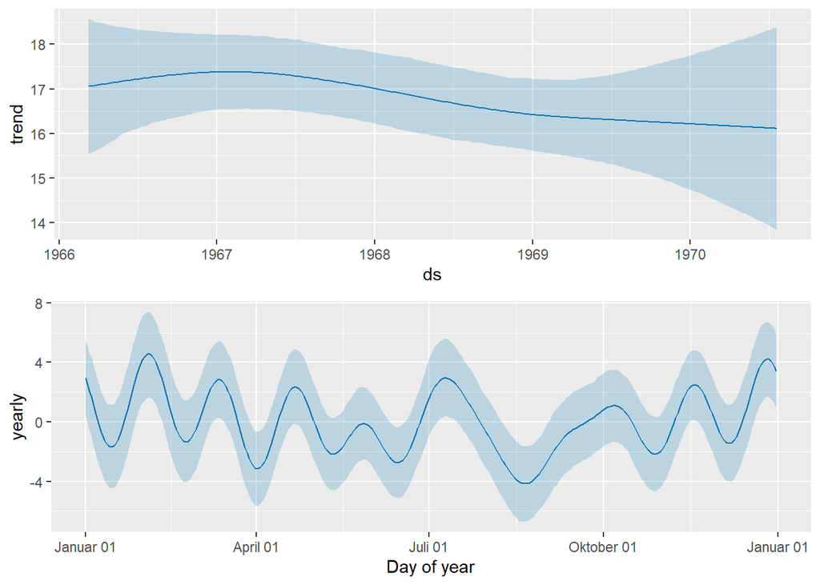

```r
# Make future dataframe for predictions
future <- make_future_dataframe(m, periods = 200) # Predict for the next 200 weeks

# Forecast
forecast <- predict(m, future)
prophet_plot_components(m, forecast, uncertainty = TRUE)
```

This could be further investigated but I don’t see any clear patterns here.

### Channel Contribution Analysis

First simple plots:

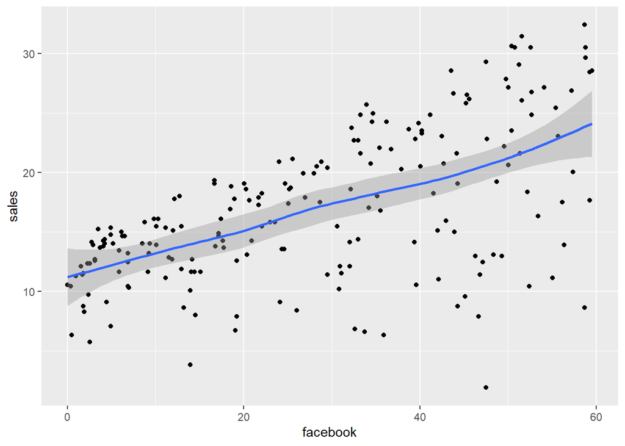

```r
# Plot sales against each channel
sampledf %>% ggplot(aes(facebook, sales)) + geom_point() + geom_smooth()
```

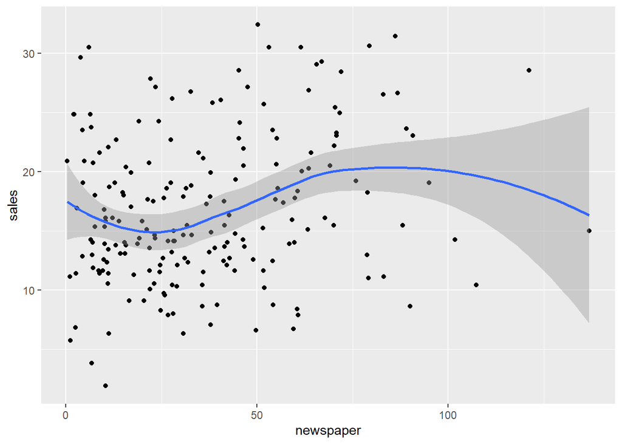

```r
sampledf %>% ggplot(aes(newspaper, sales)) + geom_point() + geom_smooth()
```

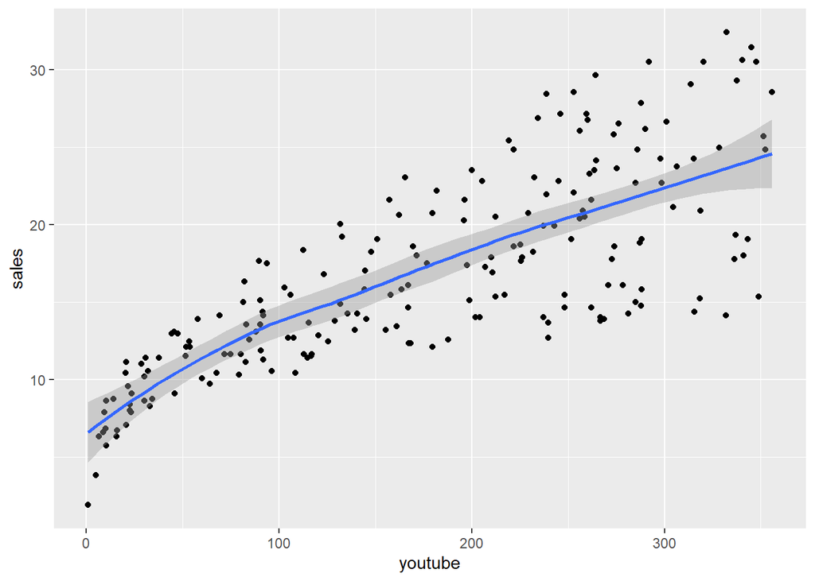

```r
sampledf %>% ggplot(aes(youtube, sales)) + geom_point() + geom_smooth()
```

### Simple Model to Identify Channel Contributions

```r
library(brms)
# Fit Bayesian regression model
m1 <- brm(sales ~ facebook + newspaper + youtube, data = sampledf)
```

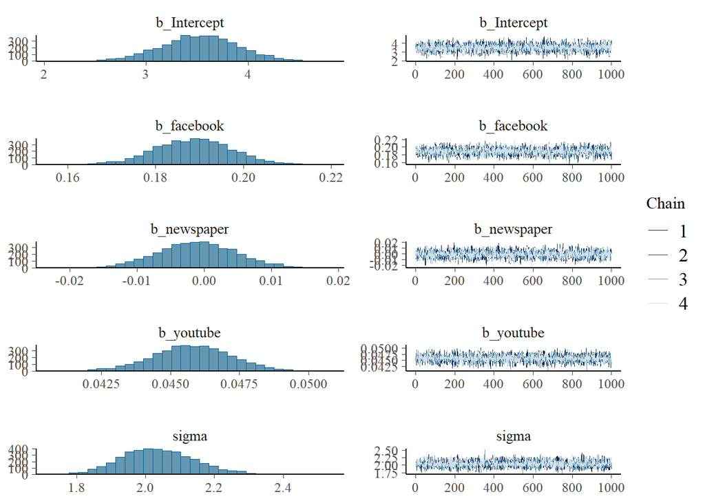

```r
plot(m1)
```

The model doesn’t return errors, and the chains mixed well.

```r
# Calculate Bayesian R-squared
bayes_R2(m1)
```

```
##     Estimate   Est.Error      Q2.5     Q97.5
## R2 0.8958453 0.004674457 0.8847498 0.9031848
```

## Results and Insights

### Model Results

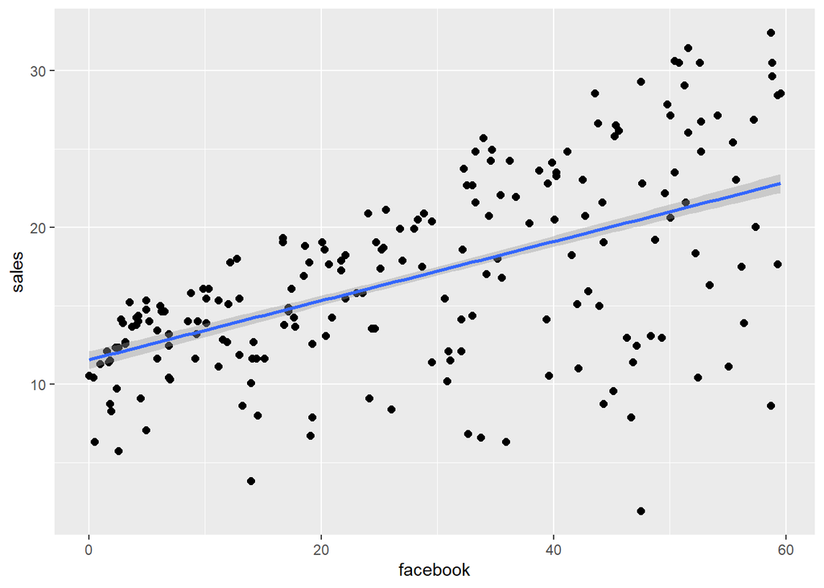

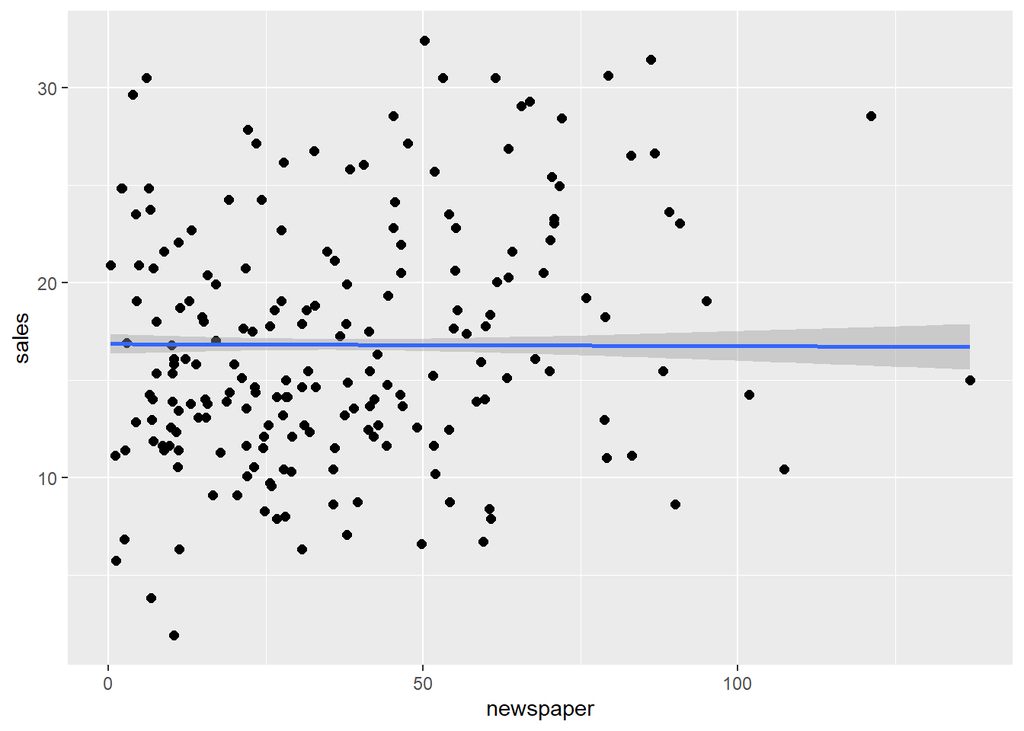

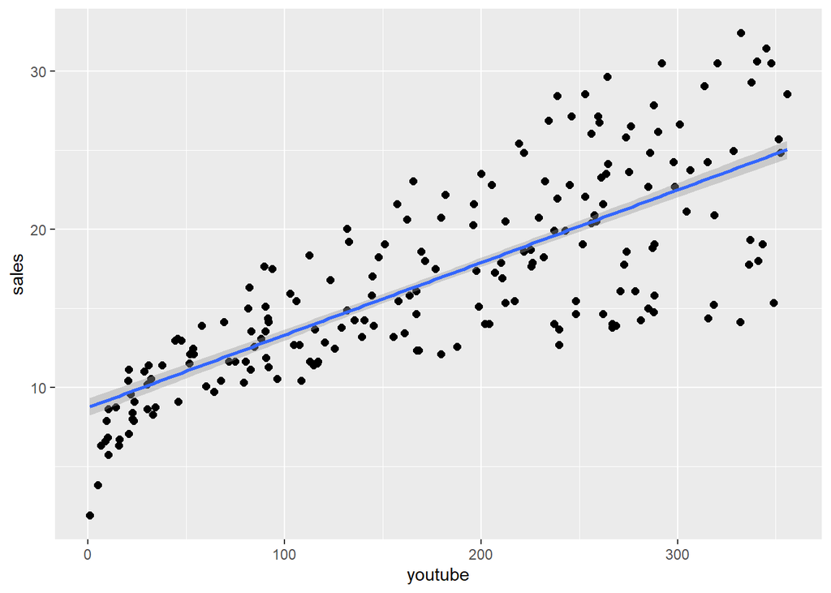

```r
# Display marginal effects and model summary
plot(conditional_effects(m1), points = TRUE, ask = FALSE)
```

```r
summary(m1)
```

```
##  Family: gaussian
##   Links: mu = identity; sigma = identity
## Formula: sales ~ facebook + newspaper + youtube
##    Data: sampledf (Number of observations: 200)
##   Draws: 4 chains, each with iter = 2000; warmup = 1000; thin = 1;
##          total post-warmup draws = 4000
##
## Regression Coefficients:
##           Estimate Est.Error l-95% CI u-95% CI Rhat Bulk_ESS Tail_ESS
## Intercept     3.52      0.38     2.77     4.24 1.00     4869     3648
## facebook      0.19      0.01     0.17     0.21 1.00     3426     2815
## newspaper    -0.00      0.01    -0.01     0.01 1.00     3305     3098
## youtube       0.05      0.00     0.04     0.05 1.00     5155     3349
##
## Further Distributional Parameters:
##       Estimate Est.Error l-95% CI u-95% CI Rhat Bulk_ESS Tail_ESS
## sigma     2.04      0.11     1.84     2.26 1.00     3407     2991
##
## Draws were sampled using sampling(NUTS). For each parameter, Bulk_ESS
## and Tail_ESS are effective sample size measures, and Rhat is the potential
## scale reduction factor on split chains (at convergence, Rhat = 1).
```

### Alternative Model with Lognormal Family

```r
# Fit Bayesian regression model with lognormal family
m2 <- brm(sales ~ facebook + newspaper + youtube, data = sampledf, family = "lognormal")
```

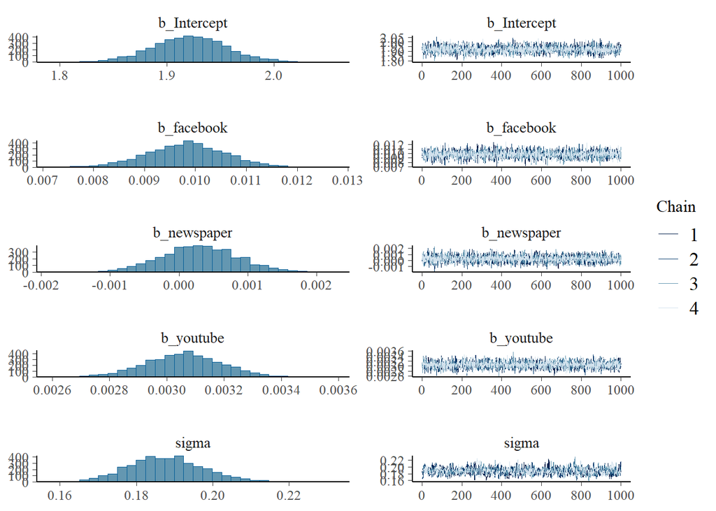

```r
plot(m2)
```

```r
# Calculate Bayesian R-squared for the lognormal model
bayes_R2(m2)
```

```
##    Estimate   Est.Error      Q2.5     Q97.5
## R2 0.906749 0.008627889 0.8870294 0.9202032
```

```r
summary(m2)
```

```
##  Family: lognormal
##   Links: mu = identity; sigma = identity
## Formula: sales ~ facebook + newspaper + youtube
##    Data: sampledf (Number of observations: 200)
##   Draws: 4 chains, each with iter = 2000; warmup = 1000; thin = 1;
##          total post-warmup draws = 4000
##
## Regression Coefficients:
##           Estimate Est.Error l-95% CI u-95% CI Rhat Bulk_ESS Tail_ESS
## Intercept     1.92      0.03     1.85     1.99 1.00     2740     3254
## facebook      0.01      0.00     0.01     0.01 1.00     3489     2472
## newspaper     0.00      0.00    -0.00     0.00 1.00     3887     2741
## youtube       0.00      0.00     0.00     0.00 1.00     4309     3137
##
## Further Distributional Parameters:
##       Estimate Est.Error l-95% CI u-95% CI Rhat Bulk_ESS Tail_ESS
## sigma     0.19      0.01     0.17     0.21 1.00     1049     1056
##
## Draws were sampled using sampling(NUTS). For each parameter, Bulk_ESS
## and Tail_ESS are effective sample size measures, and Rhat is the potential
## scale reduction factor on split chains (at convergence, Rhat = 1).
```

```r
loo1 <- loo(m1)
loo2 <- loo(m2)
compare_ic(loo1, loo2)
```

```
##           LOOIC     SE
## m1       858.89  34.92
## m2      1021.35 104.63
## m1 - m2 -162.46  76.52
```

The first model without log-normal has a better leave-one-out predictive performance.

## Conclusion

The analysis demonstrates how different marketing channels contribute to sales. The Bayesian models provide insights into the effectiveness of each channel, and the uncertainty with the potential for further refinement and exploration of additional factors.